# Data Cleaning and Data Prep

```python
# package import
import warnings
warnings.simplefilter("ignore")
warnings.filterwarnings("ignore", category=DeprecationWarning)
import pandas as pd
import numpy as np
import sklearn as sk
import matplotlib.pyplot as plt
import time
# for clustered heatmap creation
import seaborn as sns; sns.set(color_codes=True)
# for finding the MAD and IQR of ranges
import scipy
from sklearn.model_selection import GridSearchCV
from sklearn.model_selection import cross_val_score
from sklearn.ensemble import RandomForestClassifier
from sklearn.decomposition import PCA
from sklearn.preprocessing import StandardScaler
from sklearn.model_selection import train_test_split
from sklearn.manifold import TSNE
from sklearn.tree import DecisionTreeClassifier
from sklearn.pipeline import Pipeline
from sklearn.model_selection import cross_val_score, cross_val_predict
from sklearn.naive_bayes import GaussianNB
from sklearn.metrics import confusion_matrix
from sklearn.metrics import classification_report
from sklearn.neural_network import MLPClassifier
from sklearn.ensemble import AdaBoostClassifier
from boruta import BorutaPy
from sklearn.neighbors import KNeighborsClassifier
from sklearn.svm import SVC
import pickle
```

## Importing the Dataset

The dataset has 388 records which are represented as anonymized as patient barcodes beginning with "GSM..." The first four rows contains patient metadata such as gender and ethnicity. There are 32050 features in this dataset which is much fewer than the most modern assay datasets. Each feature is represented as an Illumina transcript ID starting with "ILMN..." All assays were performed on the patients' blood. By default, array datasets have records as columns and features as rows. This is because there are often many many more features than samples in bioinformatics datasets. For our analyses using Scikit-Learn and Scipy models, we will need to transpose the dataset.

```python
#import the dataset from file path
data = pd.read_csv('transposed_GSE63063.csv',header= 0)
print(data.shape)
data.head()
```

```
(32053, 390)
```

|  | Probe_ID | Patient_barcode | GSM1539409 | GSM1539410 | GSM1539411 | GSM1539412 | GSM1539413 | GSM1539414 | GSM1539415 | GSM1539416 | ... | GSM1539787 | GSM1539788 | GSM1539789 | GSM1539790 | GSM1539791 | GSM1539792 | GSM1539793 | GSM1539794 | GSM1539795 | GSM1539796 |
| --- | --- | --- | --- | --- | --- | --- | --- | --- | --- | --- | --- | --- | --- | --- | --- | --- | --- | --- | --- | --- | --- |
| 0 | NaN | Sex | Female | Female | Female | Female | Female | Female | Female | Female | ... | Male | Male | Female | Female | Male | Female | Female | Male | Male | Female |
| 1 | NaN | Condition | MCI | MCI | MCI | MCI | MCI | MCI | MCI | MCI | ... | AD | AD | MCI | MCI | MCI | MCI | MCI | AD | CTL | CTL |
| 2 | NaN | Ethnicity | Western European | Western European | Western European | Western European | Other Caucasian | Other Caucasian | Western European | Any_Other_White_Background | ... | Western European | British_English | unkown but she's white and speaks english with... | Western European | British | Western European | Western European | Western European | Western European | British_English |
| 3 | NaN | Age | 57 | 59 | 63 | 65 | 66 | 68 | 68 | 68 | ... | 79 | 73 | 83 | 80 | 86 | 83 | 83 | 82 | 88 | 86 |
| 4 | ILMN_1343291 | NaN | 12.55280722 | 12.71145907 | 13.08839335 | 12.64383051 | 13.09838903 | 13.08609968 | 13.40034321 | 12.97418372 | ... | 12.98168176 | 13.63916729 | 12.9214465 | 13.2494056 | 13.5265911 | 12.31184583 | 13.22532792 | 12.95210419 | 13.16336147 | 13.34775027 |

5 rows × 390 columns

```python
# transpose the data such that rows and columns are flipped
data = data.T
data.head()
```

|  | 0 | 1 | 2 | 3 | 4 | 5 | 6 | 7 | 8 | 9 | ... | 32043 | 32044 | 32045 | 32046 | 32047 | 32048 | 32049 | 32050 | 32051 | 32052 |
| --- | --- | --- | --- | --- | --- | --- | --- | --- | --- | --- | --- | --- | --- | --- | --- | --- | --- | --- | --- | --- | --- |
| Probe_ID | NaN | NaN | NaN | NaN | ILMN_1343291 | ILMN_1343295 | ILMN_1651209 | ILMN_1651210 | ILMN_1651221 | ILMN_1651228 | ... | ILMN_3311110 | ILMN_3311115 | ILMN_3311135 | ILMN_3311145 | ILMN_3311150 | ILMN_3311155 | ILMN_3311165 | ILMN_3311170 | ILMN_3311180 | ILMN_3311190 |
| Patient_barcode | Sex | Condition | Ethnicity | Age | NaN | NaN | NaN | NaN | NaN | NaN | ... | NaN | NaN | NaN | NaN | NaN | NaN | NaN | NaN | NaN | NaN |
| GSM1539409 | Female | MCI | Western European | 57 | 12.55280722 | 10.10155567 | 6.084670984 | 6.068804773 | 6.121059835 | 10.83398435 | ... | 6.04762 | 6.19183 | 6.13272 | 6.16856 | 6.0649 | 6.09593 | 6.20084 | 6.00451 | 6.04553 | 6.25168 |
| GSM1539410 | Female | MCI | Western European | 59 | 12.71145907 | 9.776015081 | 6.255012487 | 6.016468162 | 6.173167357 | 10.27067251 | ... | 6.08059 | 6.20489 | 6.03258 | 6.02194 | 6.08126 | 6.08884 | 6.39421 | 5.9881 | 6.03702 | 6.16483 |
| GSM1539411 | Female | MCI | Western European | 63 | 13.08839335 | 9.594397134 | 6.160484783 | 6.024321505 | 6.039552262 | 10.43059366 | ... | 6.0661 | 5.98867 | 6.11673 | 6.02284 | 6.04491 | 6.14502 | 6.08668 | 6.06621 | 6.09827 | 6.28441 |

5 rows × 32053 columns

```python
# separate the features from the labels
# patient identifiers will not be taken into account in our analyses
datax = data.drop('Patient_barcode')
# drop patient records Sex, Ethnicity, and Age
datax = datax.drop([0,2,3],axis=1)
# Pass patient Condition into data_y to be labels
datay = (data[1][2:])
# drop the labels from datax
datax.drop(1,inplace=True,axis=1)

print(datax.shape)
print(datay.shape)
datax.head()
```

```
(389, 32049)
(388,)
```

|  | 4 | 5 | 6 | 7 | 8 | 9 | 10 | 11 | 12 | 13 | ... | 32043 | 32044 | 32045 | 32046 | 32047 | 32048 | 32049 | 32050 | 32051 | 32052 |
| --- | --- | --- | --- | --- | --- | --- | --- | --- | --- | --- | --- | --- | --- | --- | --- | --- | --- | --- | --- | --- | --- |
| Probe_ID | ILMN_1343291 | ILMN_1343295 | ILMN_1651209 | ILMN_1651210 | ILMN_1651221 | ILMN_1651228 | ILMN_1651229 | ILMN_1651235 | ILMN_1651237 | ILMN_1651254 | ... | ILMN_3311110 | ILMN_3311115 | ILMN_3311135 | ILMN_3311145 | ILMN_3311150 | ILMN_3311155 | ILMN_3311165 | ILMN_3311170 | ILMN_3311180 | ILMN_3311190 |
| GSM1539409 | 12.55280722 | 10.10155567 | 6.084670984 | 6.068804773 | 6.121059835 | 10.83398435 | 6.61714565 | 6.126975706 | 6.062613209 | 9.271763244 | ... | 6.04762 | 6.19183 | 6.13272 | 6.16856 | 6.0649 | 6.09593 | 6.20084 | 6.00451 | 6.04553 | 6.25168 |
| GSM1539410 | 12.71145907 | 9.776015081 | 6.255012487 | 6.016468162 | 6.173167357 | 10.27067251 | 6.590062459 | 6.081223364 | 6.013171425 | 9.038844778 | ... | 6.08059 | 6.20489 | 6.03258 | 6.02194 | 6.08126 | 6.08884 | 6.39421 | 5.9881 | 6.03702 | 6.16483 |
| GSM1539411 | 13.08839335 | 9.594397134 | 6.160484783 | 6.024321505 | 6.039552262 | 10.43059366 | 6.509477482 | 6.08179111 | 6.012163113 | 9.059376238 | ... | 6.0661 | 5.98867 | 6.11673 | 6.02284 | 6.04491 | 6.14502 | 6.08668 | 6.06621 | 6.09827 | 6.28441 |
| GSM1539412 | 12.64383051 | 10.12678192 | 6.109219418 | 6.016117533 | 6.111306417 | 10.76520671 | 6.570108481 | 6.075929967 | 6.04603005 | 9.080948531 | ... | 6.15373 | 6.06447 | 6.02092 | 6.13735 | 6.03171 | 6.0354 | 6.27007 | 6.0053 | 6.03248 | 6.35018 |

5 rows × 32049 columns

```python
# Assign probe ID to be column titles
datax.columns = (datax.iloc[0])
# drop probe ID row
datax.drop('Probe_ID',inplace=True)

datax.head()
```

| Probe_ID | ILMN_1343291 | ILMN_1343295 | ILMN_1651209 | ILMN_1651210 | ILMN_1651221 | ILMN_1651228 | ILMN_1651229 | ILMN_1651235 | ILMN_1651237 | ILMN_1651254 | ... | ILMN_3311110 | ILMN_3311115 | ILMN_3311135 | ILMN_3311145 | ILMN_3311150 | ILMN_3311155 | ILMN_3311165 | ILMN_3311170 | ILMN_3311180 | ILMN_3311190 |
| --- | --- | --- | --- | --- | --- | --- | --- | --- | --- | --- | --- | --- | --- | --- | --- | --- | --- | --- | --- | --- | --- |
| GSM1539409 | 12.55280722 | 10.10155567 | 6.084670984 | 6.068804773 | 6.121059835 | 10.83398435 | 6.61714565 | 6.126975706 | 6.062613209 | 9.271763244 | ... | 6.04762 | 6.19183 | 6.13272 | 6.16856 | 6.0649 | 6.09593 | 6.20084 | 6.00451 | 6.04553 | 6.25168 |
| GSM1539410 | 12.71145907 | 9.776015081 | 6.255012487 | 6.016468162 | 6.173167357 | 10.27067251 | 6.590062459 | 6.081223364 | 6.013171425 | 9.038844778 | ... | 6.08059 | 6.20489 | 6.03258 | 6.02194 | 6.08126 | 6.08884 | 6.39421 | 5.9881 | 6.03702 | 6.16483 |
| GSM1539411 | 13.08839335 | 9.594397134 | 6.160484783 | 6.024321505 | 6.039552262 | 10.43059366 | 6.509477482 | 6.08179111 | 6.012163113 | 9.059376238 | ... | 6.0661 | 5.98867 | 6.11673 | 6.02284 | 6.04491 | 6.14502 | 6.08668 | 6.06621 | 6.09827 | 6.28441 |
| GSM1539412 | 12.64383051 | 10.12678192 | 6.109219418 | 6.016117533 | 6.111306417 | 10.76520671 | 6.570108481 | 6.075929967 | 6.04603005 | 9.080948531 | ... | 6.15373 | 6.06447 | 6.02092 | 6.13735 | 6.03171 | 6.0354 | 6.27007 | 6.0053 | 6.03248 | 6.35018 |
| GSM1539413 | 13.09838903 | 10.22330116 | 6.069960148 | 6.056163259 | 6.089542173 | 10.63234588 | 6.51503297 | 6.089808641 | 6.050975618 | 8.761323017 | ... | 6.06107 | 6.07591 | 6.14174 | 6.0194 | 6.03691 | 6.05405 | 6.28006 | 6.04356 | 6.15125 | 6.19059 |

5 rows × 32049 columns

```python
# export datax and datay to their own .csv files to be imported as needed
# datax.to_csv('Alzh_Features_Wrangled.csv')
# datay.to_csv('Alzh_Labels_Wrangled.csv')
```

```python
#print((datax.isnull().sum()).sum(),'Missing Values in the Dataset')
#substitute mean column values for missing values

# impute empty cells with the column supplied metric (string, float, or int)

def impute(dataset,metric='mean'):
    if metric == 'mean':
        dataset =dataset.fillna(dataset.mean(),inplace=False)
    elif metric == 'median':
        dataset =dataset.fillna(dataset.median(),inplace=False)
    elif metric == 'mode':
        dataset =dataset.fillna(dataset.mode(),inplace=False)
    elif metric == 'zero':
        dataset =dataset.fillna(0,inplace=False)
    elif type(metric) == float or type(metric) == int:
        dataset =dataset.fillna(metric,inplace=False)

    return dataset
```

```python
datay_list = list(datay)
conds = list(set(list(datay)))
print('Counts for each class:')
for i in conds:
    print("{0}: {1}".format(i,datay_list.count(i)))
```

```
Counts for each class:
AD: 139
CTL: 134
MCI to CTL: 1
CTL to AD: 1
OTHER: 1
borderline MCI: 3
MCI: 109
```

```python
AD = list(pd.Series.unique(datay))
CTL = AD.copy()
AD.remove("AD")
CTL.remove("CTL")
ADdatay = datay.replace(to_replace = AD, value = "nonAD")     #labels are AD and nonAD
CTLdatay = datay.replace(to_replace = CTL, value = "nonCTL")  #labels are CTL and nonCTL
```

## PCA

Try to determine the minimum dimensionality that would work for this

```python
def do_PCA (dataset, labels):
    #crate a scaler
    scaler = StandardScaler()
    scaled_data = scaler.fit_transform(dataset)

    pca = PCA(.95)

    pca_data = pca.fit_transform(dataset)

    print(pca.n_components_)
    pca_data_df = pd.DataFrame(pca_data)
    return(pca_data_df)

data_pca = do_PCA(datax , ADdatay)
labels = pd.DataFrame(ADdatay)
```

```
256
```

## Calculating Row Statistics for Subsetting

```python
# calculate row Var, IQR, and MAD
# Create an empty list

# turn dataframe into a 2D List full of floats
Row_list = datax.values.T.tolist()
for i in Row_list:
    for j in range(len(i)):
        i[j] = float(i[j])
# initialize empty lists
row_iqr = []
row_mad = []
row_var = []
row_std = []
# iterate through each row and find the Var, IQR, and MAD of each row
for i in Row_list:
    row_iqr.append(scipy.stats.iqr(np.asarray(i)))
    row_mad.append(scipy.stats.median_absolute_deviation(np.asarray(i)))
    row_var.append(np.var(i))
    row_std.append(np.std(i))

# sort each list to be in ascending order
sorted_row_iqr = sorted(row_iqr)
sorted_row_mad = sorted(row_mad)
sorted_row_var = sorted(row_var)
sorted_row_std = sorted(row_std)
```

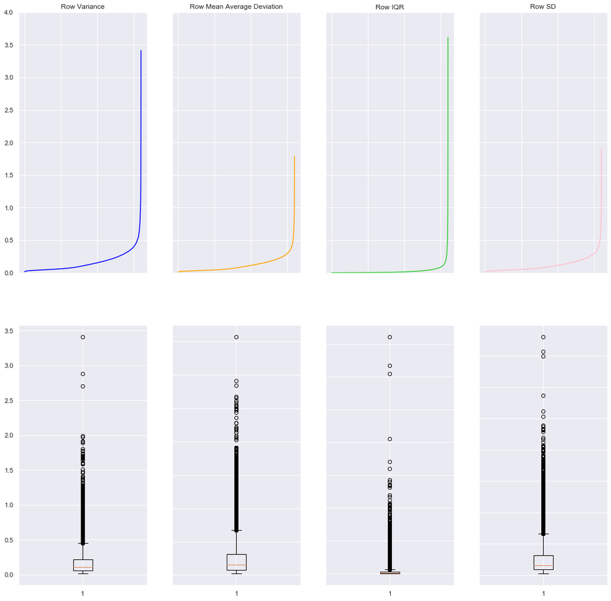

```python
# this will help us visualize how are data could be subsetted.
fig, ((ax1, ax2,ax3,ax4),(ax5,ax6,ax7,ax8)) = plt.subplots(2,4,figsize=(18,18))

ax1.plot(sorted_row_iqr,color='blue')
ax1.set_ylim([0, 4])
ax1.title.set_text('Row Variance')


ax2.plot(sorted_row_mad, color='orange')
ax2.set_ylim([0, 4])
ax2.title.set_text('Row Mean Average Deviation')

ax3.plot(sorted_row_var, color='#32cd32')
ax3.set_ylim([0, 4])
ax3.title.set_text('Row IQR')

ax4.plot(sorted_row_std, color='Pink')
ax4.set_ylim([0, 4])
ax4.title.set_text('Row SD')


ax5.boxplot(sorted_row_iqr)

ax6.boxplot(sorted_row_mad)

ax7.boxplot(sorted_row_var)

ax8.boxplot(sorted_row_std)

for ax in fig.get_axes():
    ax.label_outer()

#fig.savefig("Row_Statistics.pdf")
```

```python
from sklearn.preprocessing import StandardScaler as SS
#the following function takes six parameters: the metric list (var,iqr,mad,sd lists), the sorted metric lists,the percentile as
#an int or float, the dataset features,the string name of the metric ('iqr','var',etc.), and whether data should
# be normalized or not
def subset(metric_list,sorted_metric_list,percentile,datax,metric_string,norm = False):
    #initialize empty list for column indices
    idx_list = []
    # determine what value of the metric is at the cutoff
    threshold = (np.percentile(sorted_metric_list,percentile))
    # go through the metric list and find which columns have metric values greater than or equal to the cutoff
    for i in range(len(metric_list)):
        if metric_list[i] >= threshold:
            idx_list.append(i)
    # create and return a new dataset with only the columns that have metric values
    #greater than or equal to the cutoff
    dataset = datax.iloc[:,idx_list]
    if norm == True:
        scaler = SS()
        rownames = dataset.index
        dataset = pd.DataFrame(scaler.fit_transform(dataset),columns = dataset.columns)
        dataset.index = rownames

    if norm == False:
        filename = 'data_subset'+'_'+metric_string + '_' + str(percentile) + '_' + 'per.csv'
    else:
        filename = 'data_subset'+ '_'+ 'normalized' +'_'+metric_string + '_' + str(percentile) + '_' + 'per.csv'

    return dataset,threshold, filename
```

```python
# here, for instance, we subset the dataset features using variance and cutoff all values below the 99th percentile
# the metric used was variance, and data was normalized (via Z scoring)
datax_sub,threshold,filename = subset(row_var,sorted_row_var,99,datax,'var',norm=True)
```

```python
from pandas import DataFrame
ADdatay = DataFrame(ADdatay).rename(columns={1: "Labels"})
datax_sub_labels = pd.concat([datax_sub, ADdatay], axis=1)
datax_sub_labels.to_csv('data_subset_normalized_iqr_99_per_labels.csv')
```

```python
#write to file
#datax_sub.to_csv(filename)
# datax_sub.insert(0, "Labels", ADdatay, True)
# labels = datax_sub.pop("Labels")
# lut = dict(zip(labels.unique(), ['black','#add8e6']))
# row_colors = labels.map(lut)
# GWHM = sns.clustermap(datax_sub,method='ward',xticklabels=False,yticklabels=0,row_colors=row_colors)


# for label in labels.unique():
#     GWHM.ax_col_dendrogram.bar(0, 0, color=lut[label],
#                             label=label, linewidth=0)
# GWHM.ax_col_dendrogram.legend(loc=2, ncol=100)
```

# Classifiers

## Binary Trees

Binary trees are a great model for two reasons, they are computationally inexpensive and they are resilient to noise and redundant attributes. With our dataset being so large in terms of the number of features, a model that is capable of taking those thousands of features in stride is highly valuable. Relatedly, the fact that we are able to keep all of those features without fear that redundant attributes would throw off the whole model is also a big plus of this model.

```python
def BinaryTrees(dataset, labels):
    clf = DecisionTreeClassifier(criterion = 'entropy')

    clf = clf.fit(dataset, labels)
    params = {"max_depth": [5,10,15,20], "min_samples_leaf": [5,10,15,20], "max_features": [5,10,15]}

    grid_search = GridSearchCV(clf, params, cv = 5, scoring = 'accuracy')

    grid_search.fit(dataset, labels)

    print(grid_search.best_params_)

    print("Accuracy:", grid_search.best_score_*100)
```

## KNN

```python
def KNN(dataset, labels):
    # Define a pipeline to search for the best combination of
    # PCA dimensions and n_neighbors.

    #create a scaler
    scaler = sk.preprocessing.MinMaxScaler()

    #create a PCA
    pca = PCA()

    #create a KNN classifier
    knn = KNeighborsClassifier()

    #create a pipeline that does scaling, then PCA, then KNN
    pipe = Pipeline(steps=[('scaler', scaler), ('pca', pca), ('knn', knn)])

    #Set up the parameters you want to tune for each of your pipeline steps
    #Parameters of pipelines can be set using ‘__’ separated parameter names:
    param_grid = {
        'pca__n_components': list(range(1, 19)), #find how many principal componenet to keep
        'knn__n_neighbors': list(range(1, 30)),  #find the best value of k
    }

    # pass the pipeline and the parameters into a GridSearchCV with a 5-fold cross validation
    grid = GridSearchCV(pipe, param_grid, cv = 5, scoring = "accuracy")

    # call fit() on the GridSearchCV and pass in the unscaled data (X_values, Y_values)
    grid.fit(dataset, labels)

    # print out the best_score_ and best_params_ from the GridSearchCV
    print("Best Score:", grid.best_score_ * 100)
    print("Best Parameters:", grid.best_params_)
```

## Naive Bayes

This model is a probabilistic one. Instead of using distance between points like KNN, this model instead uses the rules of probability to classify the various points. The massive advantage of this is that a Naive Bayes model does not fall victim to the curse of dimensionality. For our dataset, this simple fact is one that makes it a potentially promising model.

```python
def NaiveBayes(dataset, labels):
    clf = GaussianNB() # set any params you may want to set

# Run a 5-fold cross validation
    scores = cross_val_score(clf, dataset, labels, cv=10)
    print("Scores:", scores)

    print("Accuracy:", scores.mean()*100)
    y_pred = cross_val_predict(clf, dataset, labels, cv=10)

    confusion_matrix(labels,y_pred)
    print(classification_report(labels, y_pred))
```

## Neural Nets

With Neural Nets the main drawbacks are that they are computationally heavy and require a lot of data to work effectively. For our dataset this is a potential area of concern. While we have 32000 features in our dataset, we only have 388 records. This means that there could be the possibility of not having sufficient data for the neural net to learn from. On the other side of things, the main advantage of a neural net is that it allows for irrelevant or redundant attributes to be taken care of through the use of 0 or similar weights (respectively)

```python
def NeuralNet(dataset, labels):
    scaler = StandardScaler()
    mlp = MLPClassifier()
    pipeline = Pipeline(steps=[('scaler', scaler),('mlp',mlp)])
    param_grid = {'mlp__hidden_layer_sizes':list(range(10,61,10)),'mlp__activation':['logistic', 'tanh', 'relu']}
    grid_search = GridSearchCV(pipeline, param_grid, cv=5, scoring='accuracy')
    y_pred = cross_val_score(grid_search, dataset, labels, cv=5)
    print(y_pred.mean())
```

## SVM

SVMs are another great model that does not fall victim to the curse of dimensionality. In addition, SVMs have known algorithms that can be used to arrive at a global minimum instead of a local minimum which is a problem that some other models have. The only real drawback to this type of model is that it can be difficult to find the right kernel function.

```python
def SVM(dataset, labels):
    # Create StandardScaler and SVC Object
    scaler = StandardScaler()
    svc = SVC()
    # Create pipeline and set steps to scaler and SVC objects
    pipe = Pipeline(steps = [('Scaler', scaler), ('svc', svc)])

    scores = cross_val_score(pipe, dataset, labels, cv = 5)
    print('Accuracy:', scores.mean() * 100)

    # for the 'svm' part of the pipeline, tune the 'kernel' hyperparameter
    param_grid = {'svc__kernel': ['linear', 'rbf', 'poly', 'sigmoid']}

    # Create GridSearchCV that takes in pipeline
    grid = GridSearchCV(pipe, param_grid, cv = 5)
    grid.fit(dataset, labels)
    print("Best kernel:", grid.best_params_)
    grid_score = cross_val_score(grid, dataset, labels, cv = 5, scoring = 'accuracy')
    print('Accuracy:', grid_score.mean() * 100)

   # Create parameter grid and GridSearchCV with pipeline from above
    params = {'svc__C': range(50, 110, 10), 'svc__kernel': ['rbf']}
    grid_search = GridSearchCV(pipe, params, cv = 5)
    # Pass the GridSearchCV into a cross_val_score with a 5-fold-CV
    grid_search_score = cross_val_score(grid_search, dataset, labels, cv = 5)
    print('Accuracy:', grid_search_score.mean() * 100)
```

## Ensembles

### AdaBoost

This algorithm is potentially highly valuable. The reason for this is that it is designed to combine multiple poorly performing classifiers into a singular good classifier. This is exactly what we are looking at with our dataset. Virtually all of our features are fairly weak so having this algorithm that is capable of turning these attributes into a strong attribute is valuable. The tradeoff with this is that the model can suffer from the curse of dimensionality which, as stated before, is a potentially big deal with our dataset.

```python
def AdaBoost(dataset, labels):
    ada = AdaBoostClassifier()
    param_grid = {'n_estimators':list(range(50,251,25))}
    grid_search = GridSearchCV(ada, param_grid, cv=5, scoring = 'accuracy')
    y_pred = cross_val_score(grid_search, dataset, labels, cv=5)
    print(y_pred.mean())
```

### Random Forest

Random forests perform well with high dimensionality data because they use a subset of the features provided. With our data having thousands of features originally and then still hundreds with extraneous features removed, models like Random Forests that can run without the need for extremely low dimensional data are incredibly useful.

```python
def RandomForest(dataset, labels):
    randomForest = RandomForestClassifier()
    param_grid = {'max_depth':list(range(35,56)), 'min_samples_leaf': [8,10,12], 'max_features':['sqrt','log2']}
    grid_search = GridSearchCV(randomForest, param_grid, cv=5, scoring='accuracy')
    y_pred = cross_val_score(grid_search, dataset, labels, cv=5)
    print(y_pred.mean())
```

### MLP

Multi-layer Perceptron (MLP) is a supervised learning algorithm that learns a function by training on a dataset. Given a set of features and a target, it can learn a non-linear function approximator.

```python
def MLP(dataset, labels):
    mlp = MLPClassifier()
    scaler = StandardScaler()
    params_final = {'mlp__activation': ['logistic', 'tanh', 'relu'], 'mlp__hidden_layer_sizes': [(10,), (20,), (30,), (40,), (50,), (60,)]}
    pipe_final = Pipeline(steps = [('Scaler', scaler), ('mlp', mlp)])
    grid_final = GridSearchCV(pipe_final, params_final, cv = 5)

    # fit GridSearchCV to determine best parameters
    grid_final.fit(dataset, datay)
    print("Best Params:", grid_final.best_params_)
    print('Accuracy:', grid_final.best_score_ * 100)

    #set this final_model to your final model
    final_model = grid_final

    filename = 'finalized_model.sav'
    pickle.dump(final_model, open(filename, 'wb'))
```

# Classifiers run with different feature engineering methods

## PCA

```python
BinaryTrees(data_pca, labels)
```

```
{'max_depth': 20, 'max_features': 5, 'min_samples_leaf': 20}
Accuracy: 61.08247422680413
```

```python
KNN(data_pca, labels)
```

```
Best Score: 64.94845360824742
Best Parameters: {'knn__n_neighbors': 25, 'pca__n_components': 1}
```

```python
NaiveBayes(data_pca, labels)
```

```
Scores: [0.56410256 0.43589744 0.56410256 0.66666667 0.61538462 0.53846154
 0.66666667 0.66666667 0.53846154 0.59459459]
Accuracy: 58.510048510048506
              precision    recall  f1-score   support

          AD       0.41      0.34      0.37       139
       nonAD       0.66      0.72      0.69       249

    accuracy                           0.59       388
   macro avg       0.53      0.53      0.53       388
weighted avg       0.57      0.59      0.58       388
```

```python
NeuralNet(data_pca, labels)
```

```
0.6468286099865047
```

```python
SVM(data_pca, labels)
```

```
Accuracy: 64.17678812415654
Best kernel: {'svc__kernel': 'sigmoid'}
```

```
Accuracy: 69.84480431848851
```

```
Accuracy: 66.24156545209176
```

```python
RandomForest(data_pca, labels)
```

```
0.6133603238866396
```

```python
AdaBoost(data_pca, labels)
```

```
0.6387989203778678
```

```python
MLP(data_pca, labels)
```

```
Best Params: {'mlp__activation': 'logistic', 'mlp__hidden_layer_sizes': (60,)}
Accuracy: 42.52577319587629
```